# Characterization of White Matter and Cerebrospinal Fluid Biomarker Associations in Alzheimer’s Disease

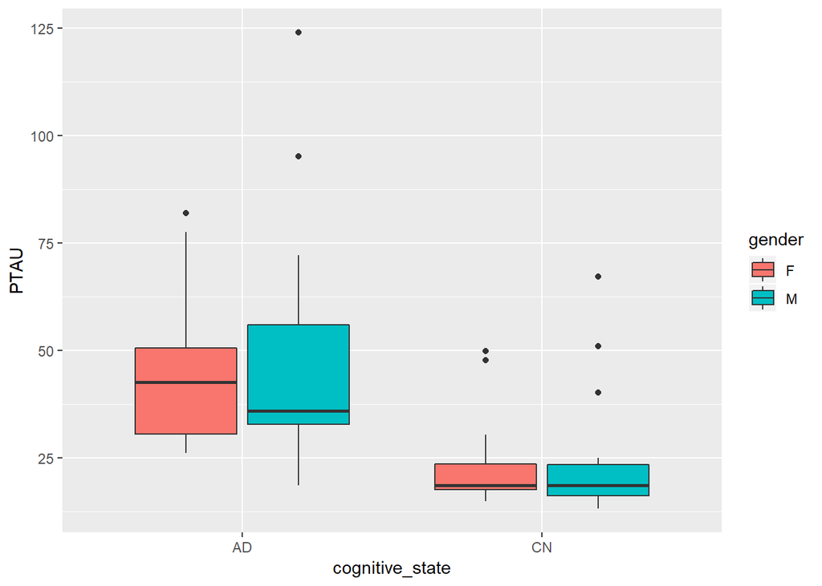

```r
ggplot(data=data_bl, aes(x=cognitive_state, y=PTAU, fill=gender)) +
    geom_boxplot()
```

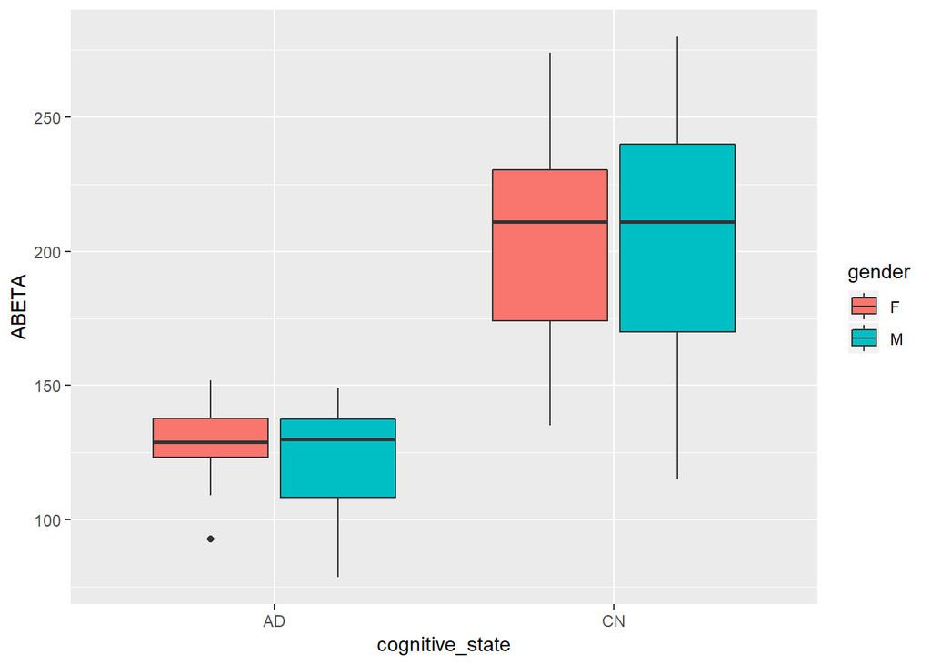

```r
## 12 month plots
ggplot(data=data_m12, aes(x=cognitive_state, y=ABETA, fill=gender)) +
    geom_boxplot()
```

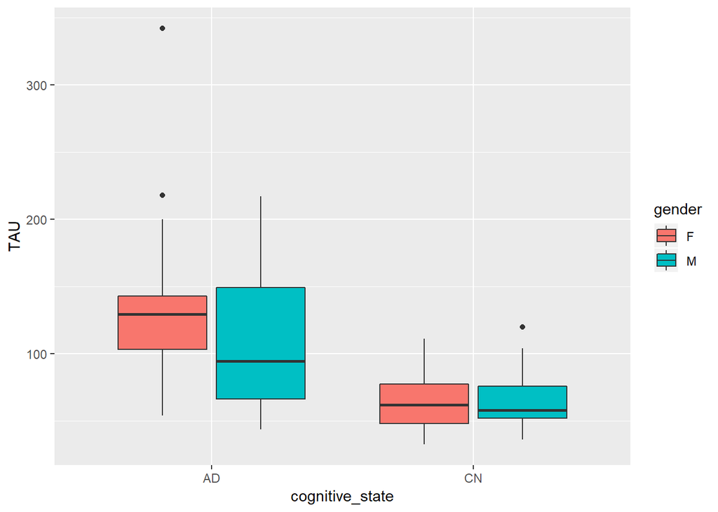

```r
ggplot(data=data_m12, aes(x=cognitive_state, y=TAU, fill=gender)) +
    geom_boxplot()
```

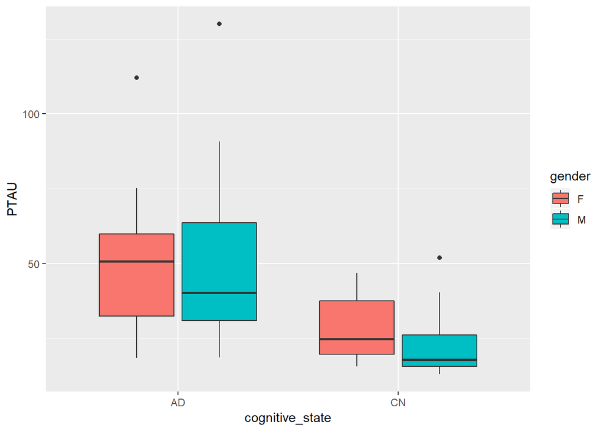

```r
ggplot(data=data_m12, aes(x=cognitive_state, y=PTAU, fill=gender)) +
    geom_boxplot()
```

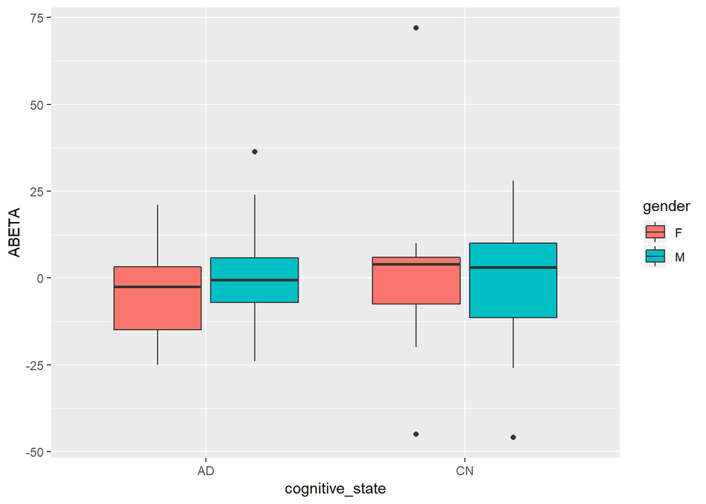

```r
## Difference Plots
ggplot(data=data_diff, aes(x=cognitive_state, y=ABETA, fill=gender)) +
    geom_boxplot()
```

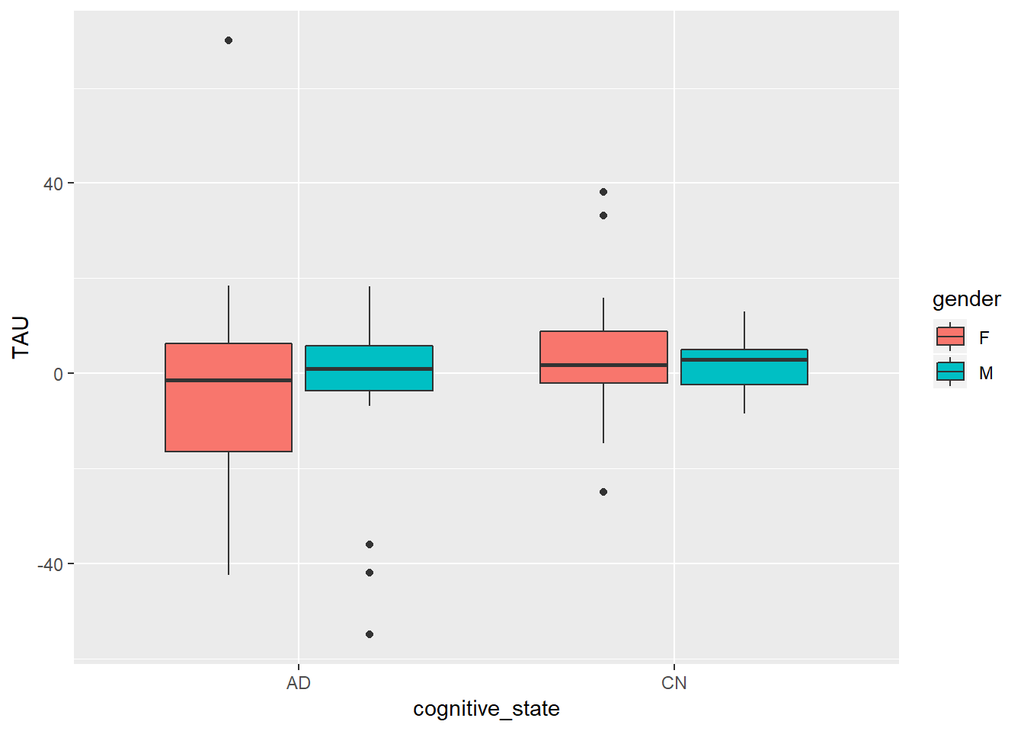

```r
ggplot(data=data_diff, aes(x=cognitive_state, y=TAU, fill=gender)) +
    geom_boxplot()
```

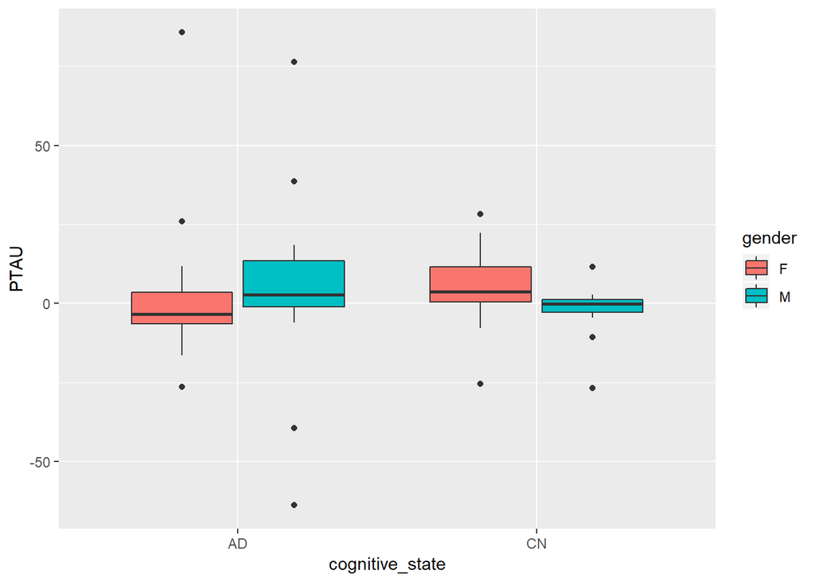

```r
ggplot(data=data_diff, aes(x=cognitive_state, y=PTAU, fill=gender)) +
    geom_boxplot()
```

Similar trends were shown as compared to the total boxplots. Male and female boxplots were similar for the same group, although some heterogeneity can be due to a small sample size.

BL Logistic Regression Bivariate Analysis:

```r
#Logistic regression, due to predicting a binary outcome from a set of continuous predictor variables
n.var <- 4
pvals <- as.list(rep(NA, n.var))
names(pvals) <- c("white_matter_ratio","ABETA","TAU","PTAU")
for (i in 1:n.var){
    glm.out <- glm(data_bl$cognitive_state ~ data_bl[[i+5]], family=binomial("logit"))
    curr.p <- coef(summary(glm.out))[,4][2]
    pvals[i] <- curr.p
}
pvals
```

```
## $white_matter_ratio
## [1] 0.001381867
##
## $ABETA
## [1] 0.0002061319
##
## $TAU
## [1] 0.0002564677
##
## $PTAU
## [1] 0.0007982111
```

All variables are associated with cognitive state at a significance level of 0.05

M12 Logistic Regression Bivariate Analysis:

```r
n.var <- 4
pvals <- as.list(rep(NA, n.var))
names(pvals) <- c("white_matter_ratio","ABETA","TAU","PTAU")
for (i in 1:n.var){
    glm.out <- glm(data_m12$cognitive_state ~ data_m12[[i+5]], family=binomial("logit"))
    curr.p <- coef(summary(glm.out))[,4][2]
    pvals[i] <- curr.p
}
pvals
```

```
## $white_matter_ratio
## [1] 0.001381867
##
## $ABETA
## [1] 0.0009628564
##
## $TAU
## [1] 0.0002673131
##
## $PTAU
## [1] 0.000404995
```

All variables are associated with cognitive state at a significance level of 0.05

Difference Logistic Regression Bivariate Analysis:

```r
n.var <- 3
pvals <- as.list(rep(NA, n.var))
names(pvals) <- c("ABETA","TAU","PTAU")
for (i in 1:n.var){
    glm.out <- glm(data_diff$cognitive_state ~ data_diff[[i+4]], family=binomial("logit"))
    curr.p <- coef(summary(glm.out))[,4][2]
    pvals[i] <- curr.p
}
pvals
```

```
## $ABETA
## [1] 0.7516279
##
## $TAU
## [1] 0.1849112
##
## $PTAU
## [1] 0.6591885
```

None of the variables are associated with cognitive state at a significance level of 0.05

All biomarkers Baseline:

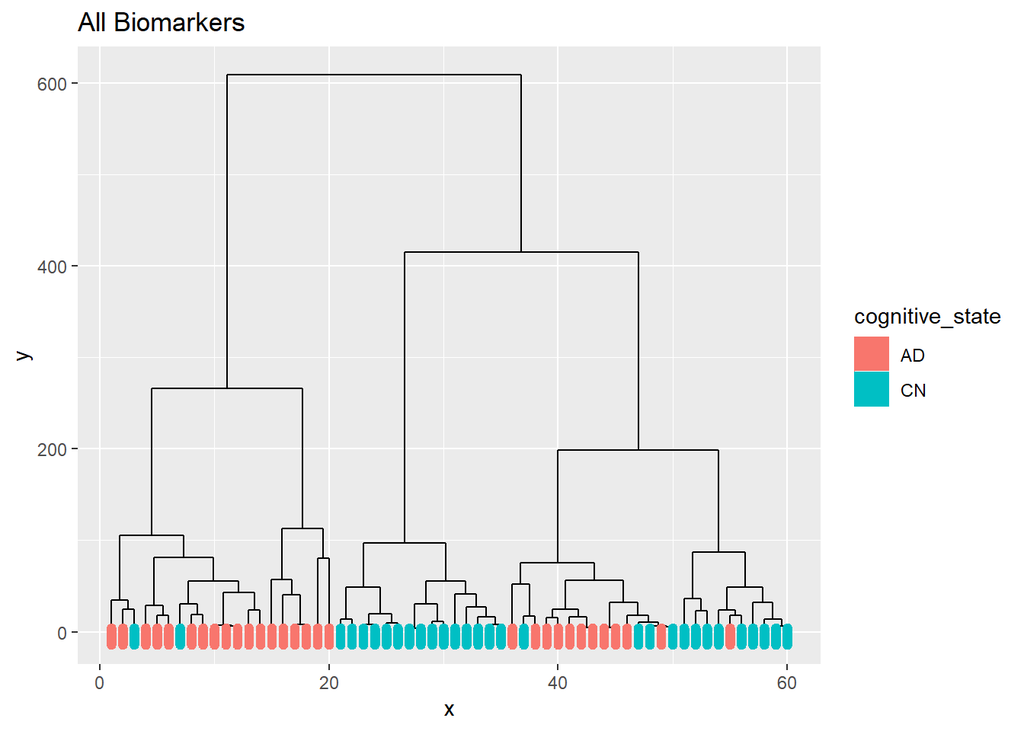

```r
library(ggdendro)
dataset.hclust1 <- hclust(dist(data_bl[,7:9]), method="ward.D2")
dataset.dend1 <- dendro_data(as.dendrogram(dataset.hclust1))
labels <- label(dataset.dend1)
labels$cognitive_state <- data_bl$cognitive_state[as.numeric(levels(labels$label))]

ggplot(segment(dataset.dend1)) +
    geom_segment(aes(x=x, y=y, xend=xend, yend=yend)) +
    ggtitle("All Biomarkers")+
    geom_label(data=labels, aes(label="", x=x, y=0, color=cognitive_state, fill=cognitive_state), stat="identity",
      nudge_y=-5,nudge_x=0,parse = FALSE,label.padding = unit(0.15, "lines"),
      label.r = unit(0.15, "lines"), label.size = 0.15, na.rm = FALSE,show.legend = NA)
```

```r
hclust.pred <- cutree(dataset.hclust1, 2)
table(data_bl$cognitive_state, hclust.pred)
```

```
##     hclust.pred
##       1  2
##   AD 12 18
##   CN 28  2
```

14 patients out of a total of 60 were clustered incorrectly.

All biomarkers with white matter content Baseline:

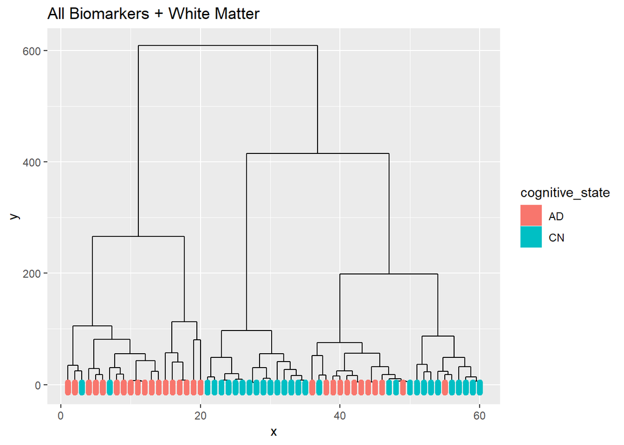

```r
library(ggdendro)
dataset.hclust1 <- hclust(dist(data_bl[,6:9]), method="ward.D2")
dataset.dend1 <- dendro_data(as.dendrogram(dataset.hclust1))
labels <- label(dataset.dend1)
labels$cognitive_state <- data_bl$cognitive_state[as.numeric(levels(labels$label))]

ggplot(segment(dataset.dend1)) +
    geom_segment(aes(x=x, y=y, xend=xend, yend=yend)) +
    ggtitle("All Biomarkers + White Matter")+
    geom_label(data=labels, aes(label="", x=x, y=0, color=cognitive_state, fill=cognitive_state), stat="identity",
      nudge_y=-5,nudge_x=0,parse = FALSE,label.padding = unit(0.15, "lines"),
      label.r = unit(0.15, "lines"), label.size = 0.15, na.rm = FALSE,show.legend = NA)
```

```r
hclust.pred <- cutree(dataset.hclust1, 2)
table(data_bl$cognitive_state, hclust.pred)
```

```
##     hclust.pred
##       1  2
##   AD 12 18
##   CN 28  2
```

14 patients out of a total of 60 were clustered incorrectly. Therefore, including white matter to biomarker data did not improve or worsen clustering.

White matter content Baseline:

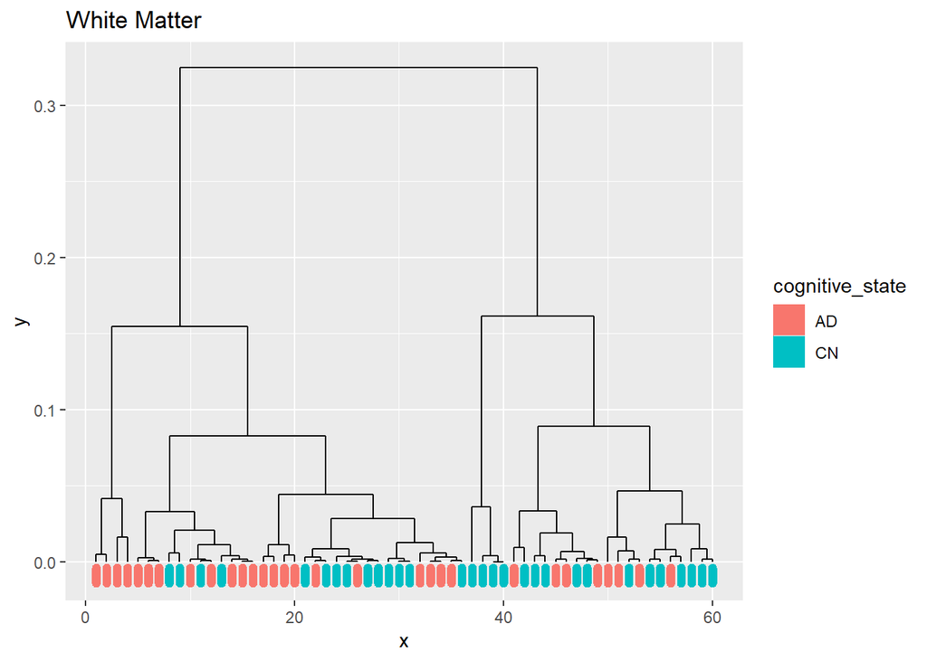

```r
library(ggdendro)
dataset.hclust1 <- hclust(dist(data_bl[,6]), method="complete")
dataset.dend1 <- dendro_data(as.dendrogram(dataset.hclust1))
labels <- label(dataset.dend1)
labels$cognitive_state <- data_bl$cognitive_state[as.numeric(levels(labels$label))]

ggplot(segment(dataset.dend1)) +
    geom_segment(aes(x=x, y=y, xend=xend, yend=yend)) +
    ggtitle("White Matter")+
    geom_label(data=labels, aes(label="", x=x, y=0, color=cognitive_state, fill=cognitive_state), stat="identity",
      nudge_y=-0.009,nudge_x=0,parse = FALSE,label.padding = unit(0.15, "lines"),
      label.r = unit(0.15, "lines"), label.size = 0.15, na.rm = FALSE,show.legend = NA)
```

```r
hclust.pred <- cutree(dataset.hclust1, 2)
table(data_bl$cognitive_state, hclust.pred)
```

```
##     hclust.pred
##       1  2
##   AD  8 22
##   CN 16 14
```

22 patients out of a total of 60 were clustered incorrectly. Just clustering with white matter content was worse than using either biomarkers or biomarkers and white matter content.

All biomarkers M12:

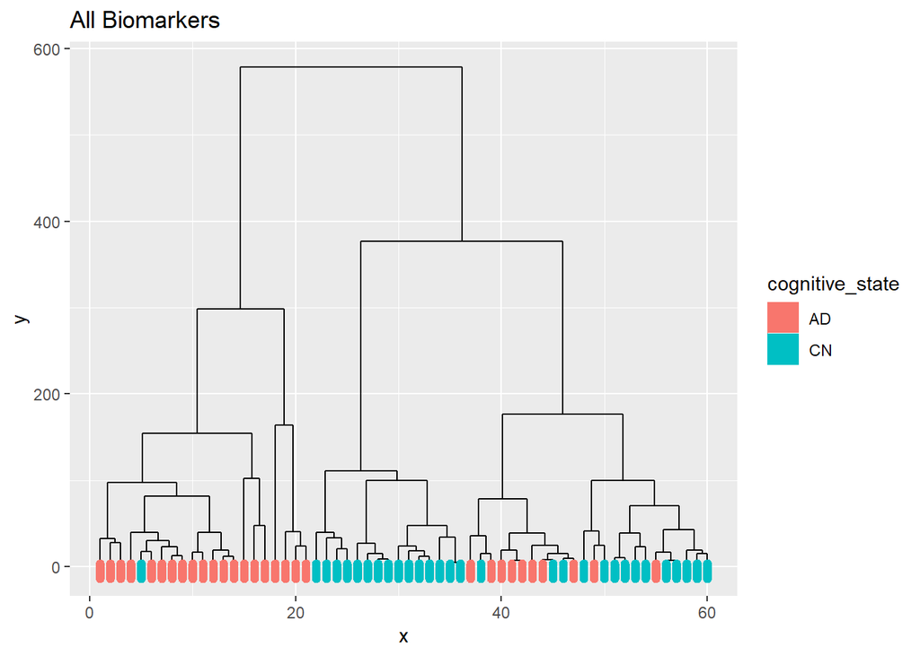

```r
library(ggdendro)
dataset.hclust1 <- hclust(dist(data_m12[,7:9]), method="ward.D2")
dataset.dend1 <- dendro_data(as.dendrogram(dataset.hclust1))
labels <- label(dataset.dend1)
labels$cognitive_state <- data_m12$cognitive_state[as.numeric(levels(labels$label))]

ggplot(segment(dataset.dend1)) +
    geom_segment(aes(x=x, y=y, xend=xend, yend=yend)) +
    ggtitle("All Biomarkers")+
    geom_label(data=labels, aes(label="", x=x, y=0, color=cognitive_state, fill=cognitive_state), stat="identity",
      nudge_y=-5,nudge_x=0,parse = FALSE,label.padding = unit(0.15, "lines"),
      label.r = unit(0.15, "lines"), label.size = 0.15, na.rm = FALSE,show.legend = NA)
```

```r
hclust.pred <- cutree(dataset.hclust1, 2)
table(data_bl$cognitive_state, hclust.pred)
```

```
##     hclust.pred
##       1  2
##   AD 10 20
##   CN 29  1
```

11 patients out of a total of 60 were clustered incorrectly. This shows an improvement of 3 patients for the 12 month data as compared to the baseline data.

All biomarkers with white matter content M12:

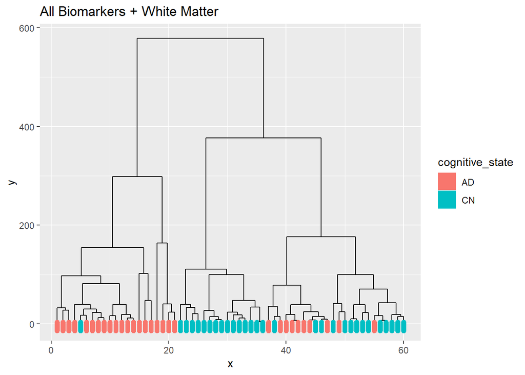

```r
library(ggdendro)
dataset.hclust1 <- hclust(dist(data_m12[,6:9]), method="ward.D2")
dataset.dend1 <- dendro_data(as.dendrogram(dataset.hclust1))
labels <- label(dataset.dend1)
labels$cognitive_state <- data_m12$cognitive_state[as.numeric(levels(labels$label))]

ggplot(segment(dataset.dend1)) +
    geom_segment(aes(x=x, y=y, xend=xend, yend=yend)) +
    ggtitle("All Biomarkers + White Matter")+
    geom_label(data=labels, aes(label="", x=x, y=0, color=cognitive_state, fill=cognitive_state), stat="identity",
      nudge_y=-5,nudge_x=0,parse = FALSE,label.padding = unit(0.15, "lines"),
      label.r = unit(0.15, "lines"), label.size = 0.15, na.rm = FALSE,show.legend = NA)
```

```r
hclust.pred <- cutree(dataset.hclust1, 2)
table(data_bl$cognitive_state, hclust.pred)
```

```
##     hclust.pred
##       1  2
##   AD 10 20
##   CN 29  1
```

11 patients out of a total of 60 were clustered incorrectly. Similar to the baseline data, including white matter content to biomarker data did not improve or worsen clustering.

Baseline Random Forest:

```r
library(randomForest)
rf <- randomForest(cognitive_state ~ white_matter_ratio + ABETA + TAU + PTAU, data=data_bl, ntree=100, importance=TRUE)
rf
```

```
##
## Call:
##  randomForest(formula = cognitive_state ~ white_matter_ratio +      ABETA + TAU + PTAU, data = data_bl, ntree = 100, importance = TRUE)
##                Type of random forest: classification
##                      Number of trees: 100
## No. of variables tried at each split: 2
##
##         OOB estimate of  error rate: 18.33%
## Confusion matrix:
##    AD CN class.error
## AD 25  5   0.1666667
## CN  6 24   0.2000000
```

```r
imp <- rf$importance
#MeanDecreaseGini
head(sort(imp[,4], decreasing=TRUE), n=20)
```

```
##              ABETA               PTAU                TAU white_matter_ratio
##          11.252526           7.615802           6.351251           4.308420
```

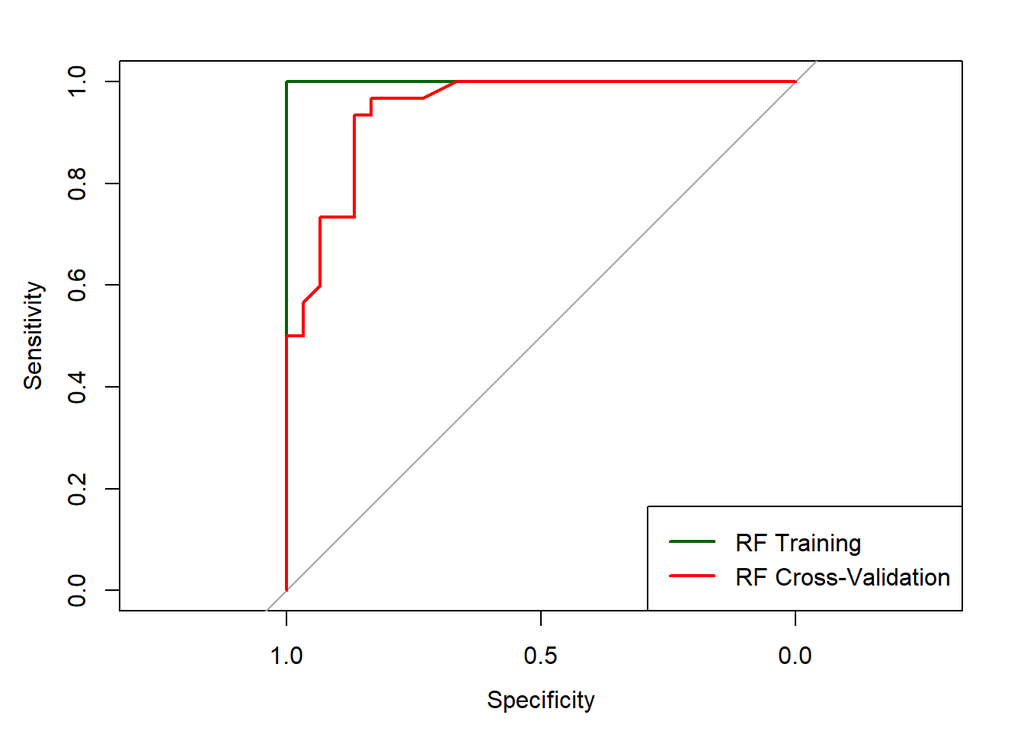

```r
rf.pred <- predict(rf, data_bl, type="prob")

N = nrow(data_bl)
K = 10
set.seed(1234)
s = sample(1:K, size=N, replace=T)
pred_outputs.rf <- vector(mode="numeric", length=N)
obs_outputs <- vector(mode="numeric", length=N)
offset <- 0
for(i in 1:K){
    train <- filter(data_bl, s != i)
    test <- filter(data_bl, s == i)
    obs_outputs[1:length(s[s==i]) + offset] <- test$cognitive_state

    #RF train/test
    rf <- randomForest(cognitive_state~white_matter_ratio + ABETA + TAU + PTAU, data=train, ntree=100)
    rf.pred.curr <- predict(rf, newdata=test, type="prob")
    pred_outputs.rf[1:length(s[s==i]) + offset] <- rf.pred.curr[,2]

    offset <- offset + length(s[s==i])
}

#ROC curves - one plot of the four tests
library(pROC)
plot.roc(data_bl$cognitive_state, rf.pred[, 2], ci=TRUE, col="darkgreen")
plot.roc(obs_outputs, pred_outputs.rf, ci=TRUE, col="red", add=TRUE)
legend("bottomright", legend=c("RF Training", "RF Cross-Validation"), col=c("darkgreen", "red"), lwd=2)
```

```r
auc(data_bl$cognitive_state, rf.pred[, 2])
```

```
## Area under the curve: 1
```

```r
auc(obs_outputs, pred_outputs.rf)
```

```
## Area under the curve: 0.945
```

According to the gini importance scores, ABETA is the most important biomarker predictor.

M12 Random Forest:

```r
rf <- randomForest(cognitive_state ~ white_matter_ratio + ABETA + TAU + PTAU, data=data_m12, ntree=100, importance=TRUE)
rf
```

```
##
## Call:
##  randomForest(formula = cognitive_state ~ white_matter_ratio +      ABETA + TAU + PTAU, data = data_m12, ntree = 100, importance = TRUE)
##                Type of random forest: classification
##                      Number of trees: 100
## No. of variables tried at each split: 2
##
##         OOB estimate of  error rate: 8.33%
## Confusion matrix:
##    AD CN class.error
## AD 29  1  0.03333333
## CN  4 26  0.13333333
```

```r
imp <- rf$importance
#MeanDecreaseGini
head(sort(imp[,4], decreasing=TRUE), n=20)
```

```
##              ABETA                TAU white_matter_ratio               PTAU
##          17.432722           4.643686           4.083012           3.354912
```

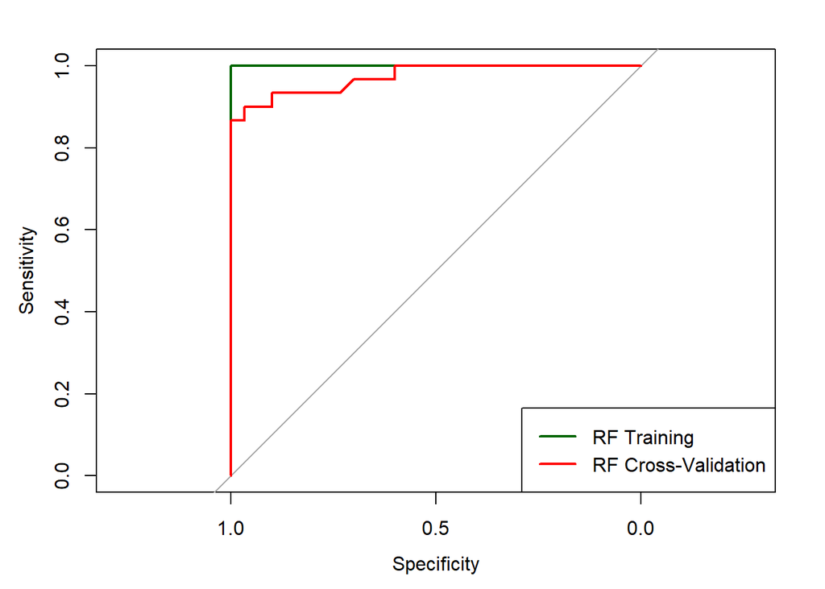

```r
rf.pred <- predict(rf, data_m12, type="prob")

N = nrow(data_m12)
K = 10
set.seed(1234)
s = sample(1:K, size=N, replace=T)
pred_outputs.rf <- vector(mode="numeric", length=N)
obs_outputs <- vector(mode="numeric", length=N)
offset <- 0
for(i in 1:K){
    train <- filter(data_m12, s != i)
    test <- filter(data_m12, s == i)
    obs_outputs[1:length(s[s==i]) + offset] <- test$cognitive_state

    #RF train/test
    rf <- randomForest(cognitive_state~white_matter_ratio + ABETA + TAU + PTAU, data=train, ntree=100)
    rf.pred.curr <- predict(rf, newdata=test, type="prob")
    pred_outputs.rf[1:length(s[s==i]) + offset] <- rf.pred.curr[,2]

    offset <- offset + length(s[s==i])
}

#ROC curves - one plot of the four tests
library(pROC)
plot.roc(data_m12$cognitive_state, rf.pred[, 2], ci=TRUE, col="darkgreen")
plot.roc(obs_outputs, pred_outputs.rf, ci=TRUE, col="red", add=TRUE)
legend("bottomright", legend=c("RF Training", "RF Cross-Validation"), col=c("darkgreen", "red"), lwd=2)
```

```r
auc(data_bl$cognitive_state, rf.pred[, 2])
```

```
## Area under the curve: 1
```

```r
auc(obs_outputs, pred_outputs.rf)
```

```
## Area under the curve: 0.9728
```

As shown by the AUC values, the RF cross-validation improved from BL to m12. This shows that there was some degree of disease progression, further differentiating AD and CN patients.

### Conclusions

Overall, white matter content ratio calculation was successful after transformation, brain extraction, and segmentation. However, the process required estimation, and is not perfectly reproducible. Even though transforming the data helped to isolate the white matter peak in the intensity histogram, the start and end intensities were chosen based on imperfect estimation. This segmentation process could be compared with segmentation using advanced normalization tools (ANTs), to assess its accuracy. White matter content displayed a significant difference between AD and CN groups after logistic regression bivariate analysis, although there was substantial overlap in the groups. This will make it difficult to predict potential future grey matter degredation using only white matter content. In terms of biomarker data, both baseline and 12 month data showed amyloid beta, tau, and p-tau biomarkers were associated with cognitive state at a significance level of 0.05. However, the difference between 12 month and baseline data was not significant. This engendered the question of whether there was any disease progression at all between baseline and 12 month timepoints. Using hierarchical clustering and random forests, both clustering and cross-validation prediction improved from baseline to 12 month timepoints, showing that there was some degree of disease progression. In addition, hierarchical clustering was used to assess white matter content. Biomarker data performed much better than white matter content in clustering, although white matter addition to biomarker data did not improve or reduce clustering accuracy for both baseline and 12 month data. A better form of characterization could be White matter integrity visualization using diffusion tensor imaging. This could determine how white matter is initially affected, as opposed to how much is affected.